# Project-1_Semunegus_Robel

Name: Robel Semunegus (rzs5yf)

https://bookdown.org/yihui/rmarkdown/html-document.html

# Introduction

The objective of this project is to use the provided data set in order to predict the locations of blue tarps within Haiti. These blue tarps indicate displaced persons who need to be rescued. The problem that the rescuers face is that there are different types of pixels/tarps as well as other types of environments (soil, vegetation, etc.) that are also a factor. The goal of this project is to determine a model that is best suited in determining the locations of the blue tarps to rescue as many people as possible. Our objective will be to test out various models and determine the optimal model that will find the most blue tarps and, thus, displaced persons.

Once the various models have been tuned, the models will then be predicted on a holdout data set to determine the level of performance that these models have. From this, the optimal model will be determined for predicting blue tarps.

# Exploratory Data Analysis (Training Data)

```r
# Source: https://aberdeenstudygroup.github.io/studyGroup/lessons/SG-T5-RMarkdown/Intro_RMarkdown/#:~:text=is%20used%20to%20specify%20any,in%20the%20final%20rendered%20version.&text=This%20will%20prevent%20the%20code,to%20a%20different%20file%20format.

data <- read.csv("HaitiPixels.csv", header=TRUE) # Load data into script
data$Class <- as.factor(data$Class) # Change to a factor/categorical
attach(data) # Attach data to script

summary(data) # Get summary statistics on data
```

```
##               Class            Red          Green            Blue
##  Blue Tarp       : 2022   Min.   : 48   Min.   : 48.0   Min.   : 44.0
##  Rooftop         : 9903   1st Qu.: 80   1st Qu.: 78.0   1st Qu.: 63.0
##  Soil            :20566   Median :163   Median :148.0   Median :123.0
##  Various Non-Tarp: 4744   Mean   :163   Mean   :153.7   Mean   :125.1
##  Vegetation      :26006   3rd Qu.:255   3rd Qu.:226.0   3rd Qu.:181.0
##                           Max.   :255   Max.   :255.0   Max.   :255.0
```

```r
cor(data[,-1]) # Create a correlation matrix of all variables except Class
```

```
##             Red     Green      Blue
## Red   1.0000000 0.9815987 0.9355294
## Green 0.9815987 1.0000000 0.9648024
## Blue  0.9355294 0.9648024 1.0000000
```

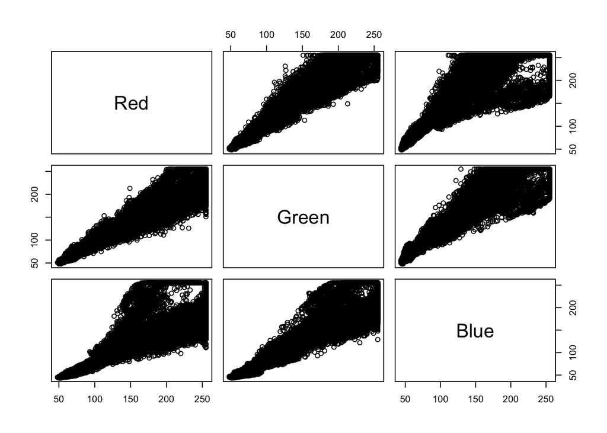

```r
pairs(data[,-1]) # Create a scatterplot matrix of all variables except Class
```

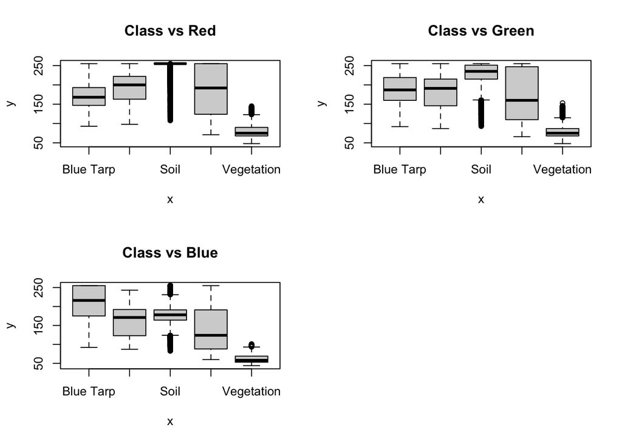

```r
# Create a plot with Class and the other quantitative variables
par(mfrow = c(2,2))
plot(Class, Red, main = "Class vs Red")
plot(Class, Green, main = "Class vs Green")
plot(Class, Blue, main = "Class vs Blue")

# Histograms
par(mfrow = c(1,3))
```

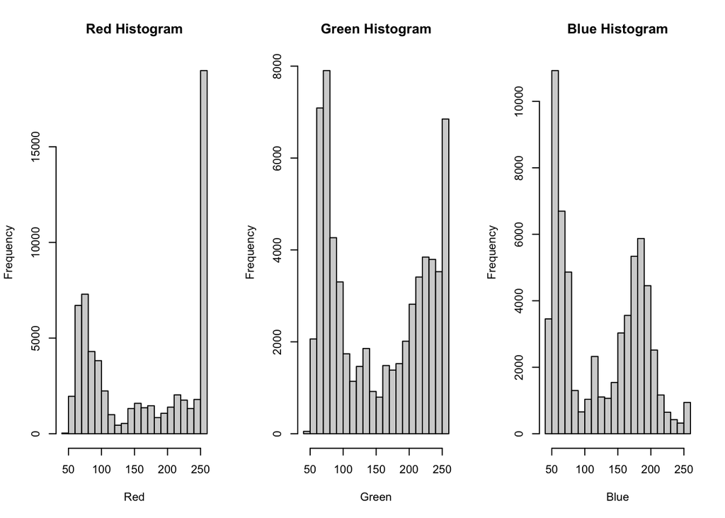

```r
hist(Red, main = "Red Histogram")
hist(Green, main = "Green Histogram")
hist(Blue, main = "Blue Histogram")
```

From the summary output, we see that three are four different variables in the data set - Class, Red, Green, and Blue. We see that Class is a qualitative variable and that Red, Green, and Blue are quantitative variables. From the output, we see that all the quantitative variables have the same max range of 255 but have different minimum and median values. Blue seems to have the smallest values within its range (but has the widest range) and Red seems to have the highest values in its range when compared to the other variables (see the mean and 3rd quantile). This makes sense because the RGB scale falls on the same range of values.

From the correlation matrix, we see that all the predictors have a high correlation with each other. From the scatterplot matrix, this high correlation is verified by the linear relationship seen in the scatter plots. From the scatterplots, we see that there seems to be a linear relationship between Blue Tarps and both the Green and Red Tarps. We can also see that there is a linear relationship between Red and Green Tarps. These scatterplots line up with what we saw in our correlation matrix previously - there are strong linear relationships between the variables.

The Class variable was converted to a categorical variable and box plots were created between Class and the three other quantitative variables. We see that the different types of classes vary between each color indicating that we can use the colors to identify the type of class seen in an image. It provides some insight that the predictors provided may be useful to our objective. We can see in the Class vs Blue box plot that the blue tarp has high values compared to the other classes (as to be expected) but not as high values in the other colors. We see that for each color, there is a likely chance that the colors will be a good indicator of blue tarps.

From the histograms, we can see the distribution of Red, Green, Blue in the data set. The histogram provides us a snapshot of where the values in those attributes lie and how often they occur. We see on the Red and Green histogram that the higher frequency values are at the ends of the histogram. For the Blue histogram, we see that the higher values seem to be on the left side and middle of the histogram.

# Model Training

## Set-up

```r
blueTarps <- ifelse(Class == "Blue Tarp", 1, 0) # Create a binary variable where 1 indicates that the observation is a blue tarp and 0 if it is not
blueTarps <- as.factor(blueTarps)
data$blueTarps <- blueTarps # Add blue tarp column to data set
```

Prior to fitting the models, a binary variable was created to indicate the observations that were Blue Tarps. We create this binary variable due to the fact that our main objective is only to determine what is and is not a blue tarp. This means that it really doesn’t matter what is in the “Not Blue Tarp” variable and we can use a binary response variable to differentiate between observations that are blue tarps and not blue tarps.

## Method Approach - Part 1

For our analysis, we will be fitting several different types of models in order to determine the optimal model and parameters that fits our model the best. The models that we will be looking at in Part 1 of this project are the following: Logistic Regression, Linear Discriminant Analysis (LDA), Quadratic Discriminant Analysis (QDA), K-Nearest Neighbors (KNN), and Ridge Regression. The overall objective of our analysis will be to perform 10-fold cross validation on each model, collect the attributes of each fold’s confusion matrix & use those attributes to calculate our metrics of interest, and then determine, from the metrics, the optimal model and associated parameters. In Part 2, we will be doing the same approach as above but for Random Forest and the Support Vector Machine (SVM) models.

To perform the analysis, as mentioned, 10-fold cross validation will be conducted (10 folds where each fold will serve as a test data at some point) and, for each fold, several metrics will be gathered. These metrics will then be summed together and divided by the number of folds to calculate the average value for each metric. The metrics that will be determined our the accuracy, precision, True Positive Rate (TPR), and False Positive Rate (FPR). To calculate these metrics, we will create a confusion matrix for each fold (and also summing up the values of the confusion matrix for each fold) and determine these metrics by looking at the features of the confusion matrix (i.e. True Positives, True Negatives, False Positives, and False Negatives). These attributes will be used as the inputs of the formulas for our metrics of interest. In addition, for each model, we will also want to take a look at the ROC curve and associated AUC value.

An optimal threshold will also have to be determined. With this threshold, we want to determine a value that helps identify the most blue tarps as possible while keeping resource constraints in mind. Also, tuning parameters will have to be identified as appropriate for each model (some models do not have tuning paramteers). These tuning parameters will be used to develop the most optimal model for each model.

Overall, the objective will be to use 10-fold cross validation to produce reliable metrics and to compare these metrics between each model. From these metrics, we will then be able to determine which model is the most optimal to reflect our data set and provide us the best chance in finding blue tarps.

## Code Implementation Approach

For each model, we use Blue, Red, and Green Tarps as our predictor values without transformations or interaction effects. For the response variable, we use our previously created binary variable (Blue Tarp or not Blue Tarp).

With the exception of Ridge Regression and SVM, we use a pretty similar implementation approach for each model to conduct our 10-fold Cross Validation. As mentioned previously, each observation in the data set is assigned a value 1 to 10 which represent the fold that it will be apart of. In this approach, each fold is looped through where one fold is assigned as the test data and the remaining 9 folds are the training data. We fit each model with the training data and then determine the probabilities and predictions associated with each fold. The code implementation to determine predictions and probabilties varied based on the model and the functions available to detremine probabilites. From the probabilities, we assign a certain threshold value to determine which predictions would be assigned a 1 (considered a Blue Tarp) or 0 (considered NOT a Blue Tarp). A confusion matrix is then developed to compare the predictions from our model with the actual results. The confusion matrix produces the TP, TN, FP, and FN values that can then be used as inputs into the formulas for our metrics of interest (accuracy, precision, TPR, and FPR - we also can determine the test error rate as well). Since we have 10 folds, we calculate an average value of these metrics for each model.

For Ridge Regression, we still perform 10-fold Cross Validation but use the cv.glmnet() function for this model, with the associated optimal lambda. From this function, we can then determine the confusion matrix values and calculate our metrics. For SVM, we use the tune() function that allow us to perform cross validation while also taking into account various values for cost/gamma/delta to determine the model with the lowest CV error and, thus, optimal parameters.

The implementation approach for the tuning parameters varied based on the model. For KNN, the optimal K-value will be determined by looking at KNN models with a K-value form 1 to 10 then determining the model with the highest K-value. For Ridge Regression, the optimal lambda is determined by the CV function and deriving the optimal lambda for that. For Random Forest, the tuning parameter is sqrt(# of parameters) since we be fitting a classification tree. For SVM, the cross validation function (tune()) will allow us to look at various values for cost/gamma/degree and find the parameters that are suitable for each kernel.

For all models, the ROC curve was created and the associated AUC value was gathered as well by collecting the probabilities into a vector.

One important item to note that, though implementation may be similar between models, the parameters and parameter values (tuning parameters, thresholds, value of K, etc.) may vary (or not exist) between each model. Later sections will describe these parameters, their selected values, and the approach to selecting these values. Also, note that each section may have some additional information on code implementation as well.

# Cross-Validation

## Logistic Regression

```r
log.result <- glm(blueTarps ~ Red + Blue + Green, data=data, family='binomial') # Create a logistic regression model with the binary variable as the response and using all the predictors
summary(log.result)
```

```
##
## Call:
## glm(formula = blueTarps ~ Red + Blue + Green, family = "binomial",
##     data = data)
##
## Deviance Residuals:
##     Min       1Q   Median       3Q      Max
## -3.4266  -0.0205  -0.0015   0.0000   3.7911
##
## Coefficients:
##             Estimate Std. Error z value Pr(>|z|)
## (Intercept)  0.20984    0.18455   1.137    0.256
## Red         -0.26031    0.01262 -20.632   <2e-16 ***
## Blue         0.47241    0.01548  30.511   <2e-16 ***
## Green       -0.21831    0.01330 -16.416   <2e-16 ***
## ---
## Signif. codes:  0 '***' 0.001 '**' 0.01 '*' 0.05 '.' 0.1 ' ' 1
##
## (Dispersion parameter for binomial family taken to be 1)
##
##     Null deviance: 17901.6  on 63240  degrees of freedom
## Residual deviance:  1769.5  on 63237  degrees of freedom
## AIC: 1777.5
##
## Number of Fisher Scoring iterations: 12
```

Before we perform cross validation, we want to see the usefulness of the predictors in our model. We see from the summary output that all 3 predictors are significant. Because we see this significance, we want to move forward with this model to determine if it is an accurate model for our objective. If so, we have no need to look into more complex formulas (transformations, interactions, etc.). The reason is that if the predictors without interaction terms and transformations are significant then there is no reason to pursue a more complex model.

```r
# Load required libraries for code
library(boot)
library(pROC)
library(glmnet)
set.seed(1) # Set the seed in order to get same results
num.rows <- dim(data)[1] # Get number of rows in the data sets
k <- 10 # Number of folds
tenFold <- rep(seq(k), times = 1 + num.rows/k)[1:num.rows] # Set observations from 1 to 10 to prepapre for cross validation
tenFold <- sample(tenFold) # Randomly assign numbers 1 to 10 for CV
```

In the code block above, we are setting up our cross validation effort by defining k as the number of folds needed for cross-validation (or CV) as well as determining the number assignment (1 to 10) for each observation to prepare for CV. Each observation is assigned a random number from 1 to 10 (since we are doing 10-fold cross validation), where each number indicates a set of observations that are cycled between training data 9 times and test data once. This code will allow us to loop through each fold and determine the appropriate metrics for each fold that will allow us to fill out our performance table.

## Cross Validation - Logistic Regression

For the logistic regression model, the glm function was used (with the family parameter set to “binomial”) for the logistic regression model.

```r
# Source: https://www.rdocumentation.org/packages/base/versions/3.6.2/topics/append
set.seed(1)

# Set metric values to 0
log.accuracy <- 0
tpr <- 0
fpr <- 0
log.precision <- 0
log.auc <- 0

log.fitted <- vector()
blueTarps.roc <- vector()
predTest <- vector()

for (eachFold in 1:k) {

  train <- data[tenFold != eachFold, ]
  test <- data[tenFold == eachFold, ]
  blueTarps.train <- blueTarps[tenFold != eachFold]
  blueTarps.test <- blueTarps[tenFold == eachFold]
  blueTarps.roc <- append(blueTarps.roc, blueTarps.test)

  log.result <- glm(blueTarps ~ Red + Blue + Green, family='binomial', data = train) # Create a logistic regression   model with the binary variable as the response and using all the predictors

  # Set confusion matrix values to 0
  tn <- 0
  fp <- 0
  fn <- 0
  tp <- 0

  # Gather the probabilities for each observation
  # Create a vector to hold the predictions
  # Determine the predictions based on the threshold value
  log.result.probs <- predict(log.result, test, type='response')
  log.result.preds <- rep(0, 6324)
  log.result.preds[log.result.probs > .14] = 1
  log.fitted <- append(log.fitted, log.result.probs)
  predTest <- append(predTest, log.result.preds)

  tn <- table(log.result.preds, blueTarps.test)[1] # Grab all the True Negatives
  fp <- table(log.result.preds, blueTarps.test)[2] # Grab all the False Positives
  fn <- table(log.result.preds, blueTarps.test)[3] # Grab all the False Negatives
  tp <- table(log.result.preds, blueTarps.test)[4] # Grab all the True Positives

  # Accuracy for each fold
  log.accuracy <- log.accuracy + ((tn+tp)/(tn+tp+fn+fp))

  # True Positive Rate for each fold
  tpr <- tpr + (tp / (tp + fn))

  # False Positive Rate for each fold
  fpr <- fpr + (fp / (fp + tn))

  # Precision for each fold
  log.precision <- log.precision + (tp / (tp + fp))

}
```

## Results - Logsitic Regression

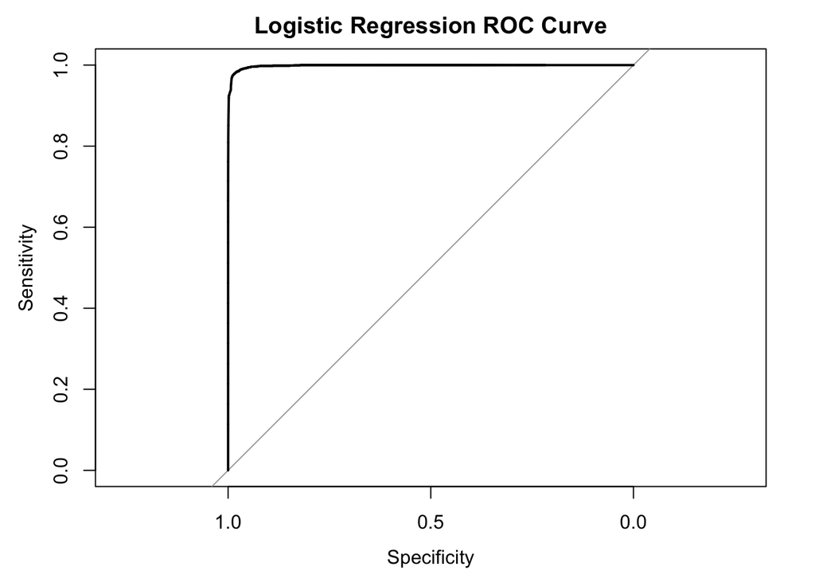

```r
# ROC and AUC
# https://www.youtube.com/watch?v=4jRBRDbJemM&t=739s
# https://www.youtube.com/watch?v=qcvAqAH60Yw&t=196s&ab_channel=StatQuestwithJoshStarmer
theLogROC <- roc(blueTarps.roc, log.fitted, plot=TRUE, main = "Logistic Regression ROC Curve")
```

```r
log.auc <- theLogROC$auc
log.auc
```

```
## Area under the curve: 0.9985
```

```r
# Accuracy of Logistic Regression Model (grab the average accuracy of all ten folds)
log.accuracy <- log.accuracy / k
log.accuracy
```

```
## [1] 0.9915403
```

```r
# Average True Positive Rate (TPR)
tpr <- tpr / k
tpr
```

```
## [1] 0.9517734
```

```r
# Average False Positive Rate (FPR)
fpr <- fpr / k
fpr
```

```
## [1] 0.007155075
```

```r
# Average Precision
log.precision <- log.precision / k
log.precision
```

```
## [1] 0.8144236
```

From our CV earlier, we were able to create a confusion matrix for each fold and grab the TP, TN, FP, and FN for each fold. Using those totals, we used these values to calculate an average of the targeted metrics (AUC, TPR, FPR, Accuracy, and Precision) by finding the total value of these metrics from all 10 folds and then dividing by 10 (the number of folds/loops). From the metrics, we see that we get high value for our AUC, Accuracy, TPR, and Precision (though precision is around ~81% while the other previous metrics are above 95%) as well as an FPR under 1%. We also can see that the test error for this model is pretty low. From our results, we see that the logistic regression model fit the data well and performed well on our test data.

Looking at the ROC curve for the logistic regression, we know that our model does much better than random guessing and this is verified by the AUC value of .9985 for the logistic regression model. The ROC curve was built from out-of-sample data (i.e. test data) - we wanted to craft our ROC curve based on the confusion matrix that was developed from the test data. It does not do as us any good to create an ROC curve from in-sample (or training) data. The ROC curve is based on the True Negative Rate (TNR) on the x-axis and True Positive Rate (TPR) on the y-axis. To do this, the probabilities of each fold were collected and fed into the ROC function against the response values of the test data.

# LDA

## Cross Validation - LDA

For the LDA regression model, the MASS library was imported and used the lda() function to fit our model using LDA.

```r
# https://www.rdocumentation.org/packages/base/versions/3.6.2/topics/append

library(MASS) # Load MASS library for LDA
set.seed(1) # Set seed to get same results

# Set metrics to 0
lda.accuracy <- 0
lda.tpr <- 0
lda.fpr <- 0
lda.precision <- 0
lda.auc <- 0

lda.fitted <- vector()
blueTarps.lda.roc <- vector()

# Conduct cross validation on the LDA model using the training data and testing on the test data from CV
for(eachFold in 1:k) {

  # Set confusion matrix values to 0  - reset for each fold
  lda.tn <- 0
  lda.fp <- 0
  lda.fn <- 0
  lda.tp <- 0

  # Split the data into training and test
  train <- data[tenFold != eachFold, ]
  test <- data[tenFold == eachFold, ]
  blueTarps.train <- blueTarps[tenFold != eachFold]
  blueTarps.test <- blueTarps[tenFold == eachFold]
  blueTarps.lda.roc <- append(blueTarps.lda.roc, blueTarps.test) # Add test response values to vector for each fold

  # Create the LDA model
  lda.model <- lda(blueTarps ~ Red + Green + Blue, data = train)

  # Grab the predictions of the LDA model using the posterior probabilities
  lda.predict <- predict(lda.model, test)
  lda.probs <- lda.predict$posterior[,2] # Gets the probability that the observations that are blue tarps

  lda.preds <- rep(0,nrow(test)) # Create vector with all 0s
  lda.preds[lda.probs > .09] = 1 # Replace zeros in above vector with 1 if above .5

  lda.predict.class <- lda.predict$class # Get the classifications of the observations

  lda.fitted <- append(lda.fitted, lda.probs) # Add probabilities of each fold to vector

  # Grab the confusion matrix values for each fold
  lda.tn <- lda.tn + table(lda.preds, blueTarps.test)[1] # Grab all the True Negatives
  lda.fp <- lda.fp + table(lda.preds, blueTarps.test)[2] # Grab all the False Positives
  lda.fn <- lda.fn + table(lda.preds, blueTarps.test)[3] # Grab all the False Negatives
  lda.tp <- lda.tp + table(lda.preds, blueTarps.test)[4] # Grab all the True Positives

  # Accuracy for each fold
  lda.accuracy <- lda.accuracy + ((lda.tn+lda.tp)/(lda.tn + lda.tp + lda.fn + lda.fp))

  # True Positive Rate for each fold
  lda.tpr <- lda.tpr + (lda.tp / (lda.tp + lda.fn))

  # False Positive Rate for each fold
  lda.fpr <- lda.fpr + (lda.fp / (lda.fp + lda.tn))

  # Precision for each fold
  lda.precision <- lda.precision + (lda.tp / (lda.tp + lda.fp))

}
```

## Results - LDA

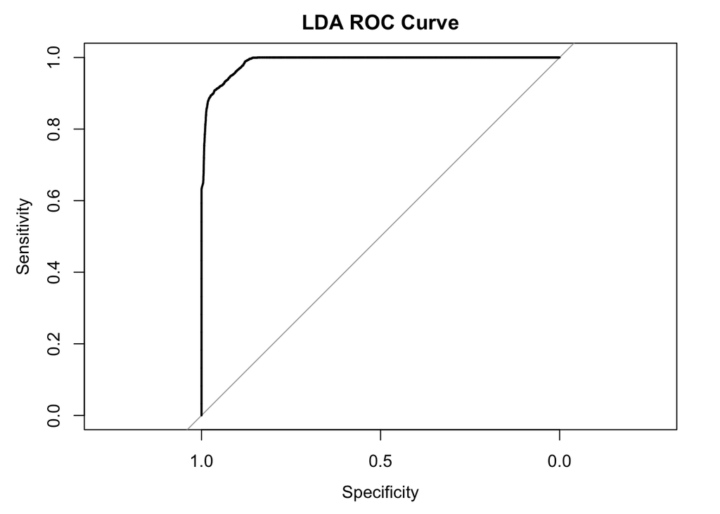

```r
# ROC and AUC
# https://www.youtube.com/watch?v=4jRBRDbJemM&t=739s
# https://www.youtube.com/watch?v=qcvAqAH60Yw&t=196s&ab_channel=StatQuestwithJoshStarmer
theLDAROC <- roc(blueTarps.lda.roc, lda.fitted, plot=TRUE, main = "LDA ROC Curve")
```

```r
lda.auc <- theLDAROC$auc
lda.auc
```

```
## Area under the curve: 0.9889
```

```r
# Accuracy of Logistic Regression Model (grab the average accuracy of all ten folds)
lda.accuracy <- lda.accuracy / k
lda.accuracy
```

```
## [1] 0.9821635
```

```r
# Average True Positive Rate (TPR)
lda.tpr <- lda.tpr / k
lda.tpr
```

```
## [1] 0.8500854
```

```r
# Average False Positive Rate (FPR)
lda.fpr <- lda.fpr / k
lda.fpr
```

```
## [1] 0.0134601
```

```r
# Average Precision
lda.precision <- lda.precision / k
lda.precision
```

```
## [1] 0.6761649
```

We see from these metrics that we get semi-decent results again though LDA did not seem to perform as well as logistic regression - there seems to be a substantial decrease in TPR and Precision in LDA as well as an FPR over 1%. We do however get a pretty low test error rate though not as low as logistic regression.

From the ROC curve, we see that our model does much better than random guessing. We can verify this by looking at the AUC for the LDA ROC curve (.9889). We see that this is a slight decrease from the AUC value that we calculated for the logistic regression ROC curve. The ROC curve for the LDA regression model was determined from out-of-sample data (i.e. test data) since we are using our model to predict on the test data and to create our confusion matrix (which the ROC curve visually informs).

# QDA

## Cross Validation - QDA

```r
# https://www.rdocumentation.org/packages/base/versions/3.6.2/topics/append

library(MASS) # Load MASS library for LDA
set.seed(1) # Set seed to get same results

# Set metrics to 0
qda.accuracy <- 0
qda.tpr <- 0
qda.fpr <- 0
qda.precision <- 0
qda.auc <- 0

qda.fitted <- vector()
blueTarps.qda.roc <- vector()


# Conduct cross validation on the QDA model using the training data and testing on the test data from CV
for(eachFold in 1:k) {

  # Split the data into training and test
  train <- data[tenFold != eachFold, ]
  test <- data[tenFold == eachFold, ]
  blueTarps.train <- blueTarps[tenFold != eachFold]
  blueTarps.test <- blueTarps[tenFold == eachFold]
  blueTarps.qda.roc <- append(blueTarps.qda.roc, blueTarps.test)

  # Set confusion matrix values to 0 for each fold
  qda.tn <- 0
  qda.fp <- 0
  qda.fn <- 0
  qda.tp <- 0

  # Create the QDA model
  qda.model <- qda(blueTarps ~ Red + Green + Blue, data = train)

  # Grab the predictions of the QDA model using the posterior probabilities
  qda.predict <- predict(qda.model, test)
  qda.probs <- qda.predict$posterior[,2] # Gets the probability that the observations that are blue tarps

  qda.preds <- rep(0,nrow(test)) # Create vector with all 0s
  qda.preds[qda.probs > .10] = 1 # Replace zeros in above vector with 1 if above .5

  qda.fitted <- append(qda.fitted, qda.probs)

  # Grab the confusion matrix values for each fold
  qda.tn <- table(qda.preds, blueTarps.test)[1] # Grab all the True Negatives
  qda.fp <- table(qda.preds, blueTarps.test)[2] # Grab all the False Positives
  qda.fn <- table(qda.preds, blueTarps.test)[3] # Grab all the False Negatives
  qda.tp <- table(qda.preds, blueTarps.test)[4] # Grab all the True Positives

  # Accuracy for each fold
  qda.accuracy <- qda.accuracy + ((qda.tn+qda.tp)/(qda.tn + qda.tp + qda.fn + qda.fp))

  # True Positive Rate for each fold
  qda.tpr <- qda.tpr + (qda.tp / (qda.tp + qda.fn))

  # False Positive Rate for each fold
  qda.fpr <- qda.fpr + (qda.fp / (qda.fp + qda.tn))

  # Precision for each fold
  qda.precision <- qda.precision + (qda.tp / (qda.tp + qda.fp))

}
```

## Results - QDA

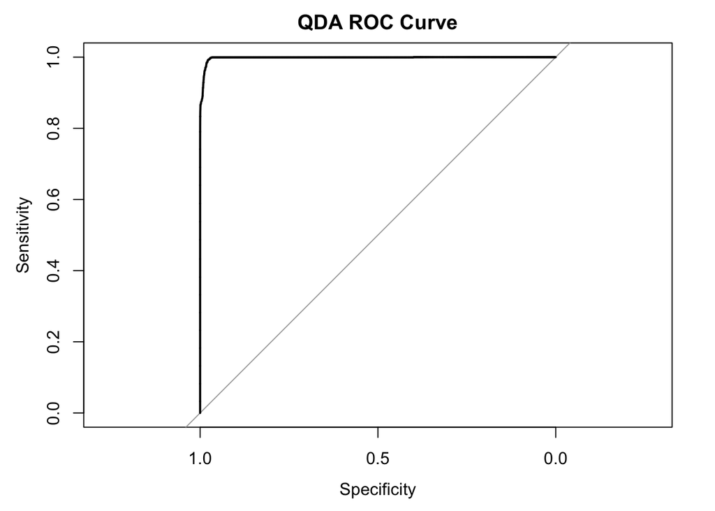

```r
# ROC and AUC
# https://www.youtube.com/watch?v=4jRBRDbJemM&t=739s
# https://www.youtube.com/watch?v=qcvAqAH60Yw&t=196s&ab_channel=StatQuestwithJoshStarmer
theQDAROC <- roc(blueTarps.qda.roc, qda.fitted, plot=TRUE, main = "QDA ROC Curve")
```

```r
qda.auc <- theQDAROC$auc
qda.auc
```

```
## Area under the curve: 0.9982
```

```r
# Accuracy of Logistic Regression Model (grab the average accuracy of all ten folds)
qda.accuracy <- qda.accuracy / k
qda.accuracy
```

```
## [1] 0.9896902
```

```r
# Average True Positive Rate (TPR)
qda.tpr <- qda.tpr / k
qda.tpr
```

```
## [1] 0.9014926
```

```r
# Average False Positive Rate (FPR)
qda.fpr <- qda.fpr / k
qda.fpr
```

```
## [1] 0.00738443
```

```r
# Average Precision
qda.precision <- qda.precision / k
qda.precision
```

```
## [1] 0.8017443
```

Looking at the metrics for QDA, we that the QDA model performs pretty well. We see that QDA performs almost as well as logistic regression and has a noticeable improvement over LDA (though it has a slightly higher test error). It seems, though, that the data fits a quadratic boundary better than it fits a linear boundary (though the LDA model did perform relatively well). This seems to suggest that our data seems to have some non-linearity and requires a model with more flexibility than what LDA regression can offer.

From the ROC curve, again, we see that our model does better than random guessing. The AUC values verify this (.9982) and we see that this is slightly below the AUC of the logistic regression model and slightly higher than the LDA AUC value. The ROC curve was built from out-of-sample data.

# KNN

## Cross Validation - KNN

```r
knnFunction <- function(kValue, metric, roc) {

  library(class)
  library(caret)

  set.seed(1)

  # Set metrics to 0
  knn.accuracy <- 0
  knn.tpr <- 0
  knn.fpr <- 0
  knn.precision <- 0
  knn.auc <- 0

  # Create vectors to use for the ROC curve (probabilities and test response values)
  knn.fitted <- vector()
  blueTarps.knn.roc <- vector()

  for(eachFold in 1:k) {

    train <- data[tenFold != eachFold, ]
    test <- data[tenFold == eachFold, ]
    blueTarps.train <- blueTarps[tenFold != eachFold]
    blueTarps.test <- blueTarps[tenFold == eachFold]
    blueTarps.knn.roc <- append(blueTarps.knn.roc, blueTarps.test) # Add response values from test data from each    fold

    # Set confusion matrix values to 0
    knn.tn <- 0
    knn.fp <- 0
    knn.fn <- 0
    knn.tp <- 0

    # Grab the probabilities using the caret library
    # Source: https://daviddalpiaz.github.io/stat432sp18/supp/knn_class_r.html
    knn.model <- knn3(blueTarps~Red + Green + Blue, data = train, k = kValue)
    knn.probs <- predict(knn.model, test, type='prob')[,2]

    knn.preds <- rep(0, nrow(test))
    knn.preds[knn.probs > .59] = 1

    knn.fitted <- append(knn.fitted, knn.probs)

    # Grab the predictions of the KNN model
    # knn.predict <- knn(train.predictors, test.predictors, blueTarps.train, k = 1)

    # Grab the confusion matrix values for each fold
    knn.tn <- table(knn.preds, blueTarps.test)[1] # Grab all the True Negatives
    knn.fp <- table(knn.preds, blueTarps.test)[2] # Grab all the False Positives
    knn.fn <- table(knn.preds, blueTarps.test)[3] # Grab all the False Negatives
    knn.tp <- table(knn.preds, blueTarps.test)[4] # Grab all the True Positives

    # Accuracy for each fold
    knn.accuracy <- knn.accuracy + ((knn.tn+knn.tp)/(knn.tn + knn.tp + knn.fn + knn.fp))

    # True Positive Rate for each fold
    knn.tpr <- knn.tpr + (knn.tp / (knn.tp + knn.fn))

    # False Positive Rate for each fold
    knn.fpr <- knn.fpr + (knn.fp / (knn.fp + knn.tn))

    # Precision for each fold
    knn.precision <- knn.precision + (knn.tp / (knn.tp + knn.fp))

  }

  if (roc == "Yes") {
    theKNNROC <- roc(blueTarps.knn.roc, knn.fitted, plot=TRUE, main = "KNN ROC Curve")
    knn.auc <- theKNNROC$auc
  }
  else if (roc == "No") {
    theKNNROC <- roc(blueTarps.knn.roc, knn.fitted, plot=FALSE, main = "KNN ROC Curve")
    knn.auc <- theKNNROC$auc
  }

  # SOURCES
  # https://swcarpentry.github.io/r-novice-inflammation/02-func-R/
  # https://www.datamentor.io/r-programming/return-function/

  if (metric == "AUC") {
    return(knn.auc)
  }
  else if (metric == "Accuracy") {
    return(knn.accuracy/k)
  }
  else if (metric == "TPR") {
    return(knn.tpr/k)
  }
  else if (metric == "FPR") {
    return(knn.fpr/k)
  }
  else if (metric == "Precision") {
    return(knn.precision/k)
  }
  else if (metric == "Test Error") {
    return(knn.te/k)
  }

}
```

## Results - KNN

```r
knn.auc.1 <- knnFunction(1, "AUC", "No")
knn.auc.2 <- knnFunction(2, "AUC", "No")
knn.auc.3 <- knnFunction(3, "AUC", "No")
knn.auc.4 <- knnFunction(4, "AUC", "No")
knn.auc.5 <- knnFunction(5, "AUC", "No")
knn.auc.6 <- knnFunction(6, "AUC", "No")
knn.auc.7 <- knnFunction(7, "AUC", "No")
knn.auc.8 <- knnFunction(8, "AUC", "No")
knn.auc.9 <- knnFunction(9, "AUC", "No")
knn.auc.10 <- knnFunction(10, "AUC", "No")
```

For KNN, we used the “caret” library in order to determine both the probabilities and predictions for the KNN model from our cross validation. A threshold of .59 was used (see Threshold Justification section) to compare the estimated probabilities of the test data. The knn3() function from the caret library was used to create the KNN model and to determine the probabilities (to be used for the ROC curve later). The probabilities collected were the probabilities associated with the percent chance that the observation was a blue tarp.

Additionally, as can be seen, multiple KNN models were created using various values of K for the tuning parameter of the KNN models. See the Tuning Parameter section for the KNN model for more details on why K = 10 was chosen as the value of the tuning parameter.

## Results - KNN

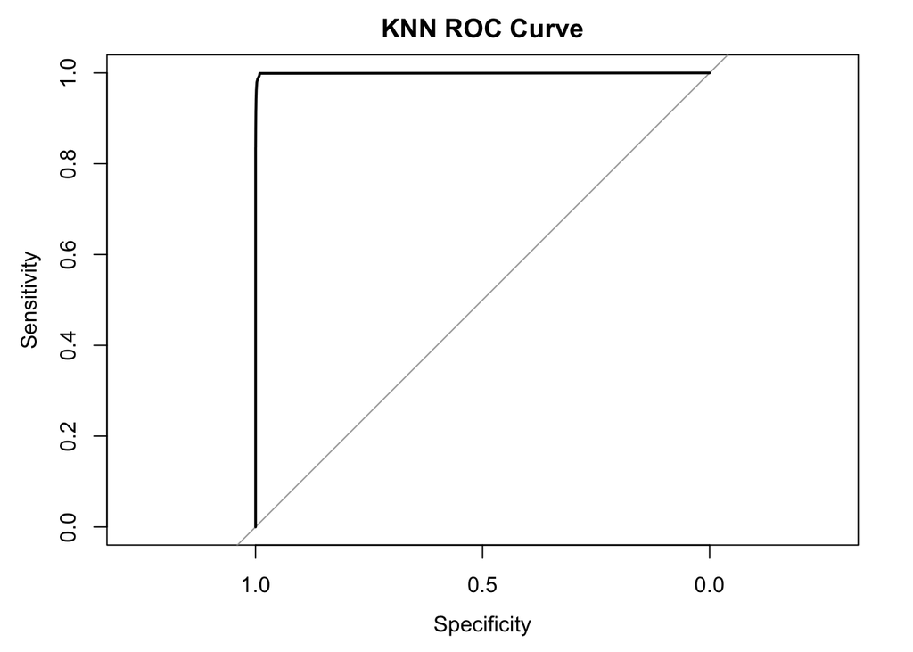

```
## Area under the curve: 0.9992
```

```r
# ROC and AUC
# https://www.youtube.com/watch?v=4jRBRDbJemM&t=739s
# https://www.youtube.com/watch?v=qcvAqAH60Yw&t=196s&ab_channel=StatQuestwithJoshStarmer

#AUC
#theKNNROC <- roc(blueTarps.knn.roc, knn.fitted, plot=TRUE, main = "KNN ROC Curve")
#knn.auc <- theKNNROC$auc
knnFunction(10, "AUC", "Yes")
```

```r
#knn.auc.10

# Accuracy of Logistic Regression Model (grab the average accuracy of all ten folds)
knn.accuracy <- knnFunction(10,"Accuracy", "No")
knn.accuracy
```

```
## [1] 0.9970431
```

```r
# Average True Positive Rate (TPR)
knn.tpr <- knnFunction(10, "TPR", "No")
knn.tpr
```

```
## [1] 0.9540529
```

```r
# Average False Positive Rate (FPR)
knn.fpr <- knnFunction(10, "FPR", "No")
knn.fpr
```

```
## [1] 0.001534872
```

```r
# Average Precision
knn.precision <- knnFunction(10, "Precision", "No")
knn.precision
```

```
## [1] 0.9531316
```

From the metrics, the KNN model has the highest AUC value and TPR compared to logistic regression, LDA, and QDA. It also seems to have the highest accuracy value compared to the previous models as well. THe KNN model with K = 10 seems to also have the lowest FPR value as well. From these metrics, it seems that KNN outperforms the other 3 models for all metrics. It is also the only model so far with a precision higher than 90%. The ROC curve was also once again built from out-of-sample data.

# Penalized Logistic Regression (Ridge Regression)

## Cross-Validation - Ridge Regression

The ridge regression model was created by using the cv.glmnet() function and set lambda to be the optimal lambda determined by cross validation. We also make sure to specify that the alpha value is 0 since we want to perform ridge regression and not lasso regression. Since we are dealing with a binary response variable, we include the specification that the family attribute is binomial.

```r
library(glmnet) # Library loaded for ridge and lasso

# Set confusion matrix values to 0
ridge.tn <- 0
ridge.fp <- 0
ridge.fn <- 0
ridge.tp <- 0

# Set metrics to 0
ridge.accuracy <- 0
ridge.tpr <- 0
ridge.fpr <- 0
ridge.precision <- 0
ridge.auc <- 0

set.seed(1) # Set seed to get consistent results

matrix.pred <- model.matrix(blueTarps~Red+Blue+Green, data)[,-1] # Create a matrix of the predictors

sample.seed <- sample(1:nrow(data), nrow(data)/2) # Create sample seed for test and training split
cv.output <- cv.glmnet(matrix.pred[sample.seed,], blueTarps[sample.seed], family = 'binomial', alpha = 0)

optimal.lambda <- cv.output$lambda.min # Get the optimal lambda from CV
optimal.lambda
```

```
## [1] 0.004151254
```

```r
#Create ridge regression model
ridge.model <- glmnet(matrix.pred[sample.seed,], blueTarps[sample.seed], alpha = 0, lambda = optimal.lambda, family = 'binomial')

# Grab the probabilities and predictions from the ridge model
ridge.predict <- predict(ridge.model, s = optimal.lambda, newx = matrix.pred[-sample.seed,], type = 'response')

ridge.preds <- rep(0, length(blueTarps[-sample.seed]))
ridge.preds[ridge.predict > .01] = 1

# Grab the confusion matrix values for each fold
ridge.tn <- table(ridge.preds, blueTarps[-sample.seed])[1] # Grab all the True Negatives
ridge.fp <- table(ridge.preds, blueTarps[-sample.seed])[2] # Grab all the False Positives
ridge.fn <- table(ridge.preds, blueTarps[-sample.seed])[3] # Grab all the False Negatives
ridge.tp <- table(ridge.preds, blueTarps[-sample.seed])[4] # Grab all the True Positives
```

Through cross validation, we can also determine the optimal value for our tuning parameter, lambda (in this case it is ~.004 - see justification for optimal lambda value in Tuning Parameters section). We also needed to create a model matrix for the predictor values in order to create our ridge regression and define it as a binomial. This matrix was created by taking our model and creating a matrix using the response variable against the predictors. For our splitting of the data between training and test data, we split the data in half to perform our cross validation compared to where we assigned observations a value 1-10 and set each set of values as test data for each fold in the other models. Similar to our other models, we use a threshold value of .01 (see Threshold Selection section) to reduce the number of false negatives where it predicts a blue tarp as not being a blue tarp since we want to find as many people as possible.

## Results - Ridge Regression

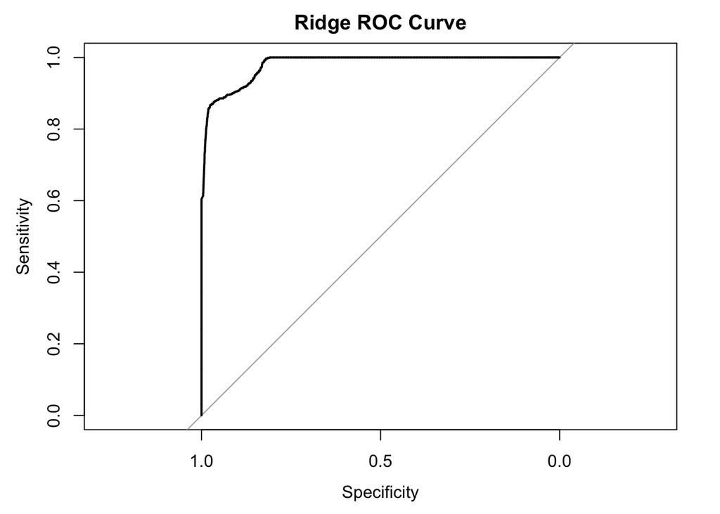

```r
# ROC and AUC
theRidgeROC <- roc(blueTarps[-sample.seed], ridge.predict, plot=TRUE, main="Ridge ROC Curve")
```

```r
ridge.auc <- theRidgeROC$auc
ridge.auc
```

```
## Area under the curve: 0.9809
```

```r
# Accuracy for each fold
ridge.accuracy <- ((ridge.tn+ridge.tp)/(ridge.tn + ridge.tp + ridge.fn + ridge.fp))
ridge.accuracy
```

```
## [1] 0.1675785
```

```r
# True Positive Rate for each fold
ridge.tpr <- (ridge.tp / (ridge.tp + ridge.fn))
ridge.tpr
```

```
## [1] 1
```

```r
# False Positive Rate for each fold
ridge.fpr <- (ridge.fp / (ridge.fp + ridge.tn))
ridge.fpr
```

```
## [1] 0.8598027
```

```r
# Precision for each fold
ridge.precision <- (ridge.tp / (ridge.tp + ridge.fp))
ridge.precision
```

```
## [1] 0.03684731
```

# Random Forest

## Cross-Validation - Random Forest

In random forest, we are fitting a classification tree to the data using the randomForest() function. Because of this, our tuning parameter for “mtry” (or the number of predictors considered at each branch) would be the square root of 3 (see Threshold Justification section).

```r
# https://www.rdocumentation.org/packages/base/versions/3.6.2/topics/append

library(randomForest) # Load MASS library for Random Forest (RF)
set.seed(1)

# Set metrics to 0
rf.accuracy <- 0
rf.tpr <- 0
rf.fpr <- 0
rf.precision <- 0
rf.auc <- 0
rf.te <- 0

rf.fitted <- vector()
blueTarps.rf.roc <- vector()

# Conduct cross validation on the RF model using the training data and testing on the test data from CV
for(eachFold in 1:k) {

  # Set confusion matrix values to 0  - reset for each fold
  rf.tn <- 0
  rf.fp <- 0
  rf.fn <- 0
  rf.tp <- 0

  # Split the data into training and test
  train <- data[tenFold != eachFold, ]
  test <- data[tenFold == eachFold, ]
  blueTarps.train <- blueTarps[tenFold != eachFold]
  blueTarps.test <- blueTarps[tenFold == eachFold]
  blueTarps.rf.roc <- append(blueTarps.rf.roc, blueTarps.test) # Add test response values to vector for each fold

  # Create the Random Forest model
  rf.model <- randomForest(blueTarps ~ Red + Green + Blue, data = train, mtry = sqrt(3), importance=TRUE)

  # Grab the predictions of the Random Forest model
  #rf.preds <- predict(rf.model, newdata = test, type='prob')
  # https://stats.stackexchange.com/questions/226109/how-does-predict-randomforest-estimate-class-probabilities
  rf.probs <- predict(rf.model, newdata = test, type = 'prob')
  rf.preds <- rep(0,nrow(test)) # Create vector with all 0s
  rf.preds[rf.probs[,2] > .45] = 1 # Replace zeros in above vector with 1 if above .5

  rf.fitted <- append(rf.fitted, rf.probs[,2]) # Add probabilities of each fold to vector

  # Grab the confusion matrix values for each fold
  rf.tn <- rf.tn + table(rf.preds, blueTarps.test)[1] # Grab all the True Negatives
  rf.fp <- rf.fp + table(rf.preds, blueTarps.test)[2] # Grab all the False Positives
  rf.fn <- rf.fn + table(rf.preds, blueTarps.test)[3] # Grab all the False Negatives
  rf.tp <- rf.tp + table(rf.preds, blueTarps.test)[4] # Grab all the True Positives

  # Accuracy for each fold
  rf.accuracy <- rf.accuracy + ((rf.tn + rf.tp)/(rf.tn + rf.tp + rf.fn + rf.fp))

  # True Positive Rate for each fold
  rf.tpr <- rf.tpr + (rf.tp / (rf.tp + rf.fn))

  # False Positive Rate for each fold
  rf.fpr <- rf.fpr + (rf.fp / (rf.fp + rf.tn))

  # Precision for each fold
  rf.precision <- rf.precision + (rf.tp / (rf.tp + rf.fp))

}
```

## Results - Random Forest

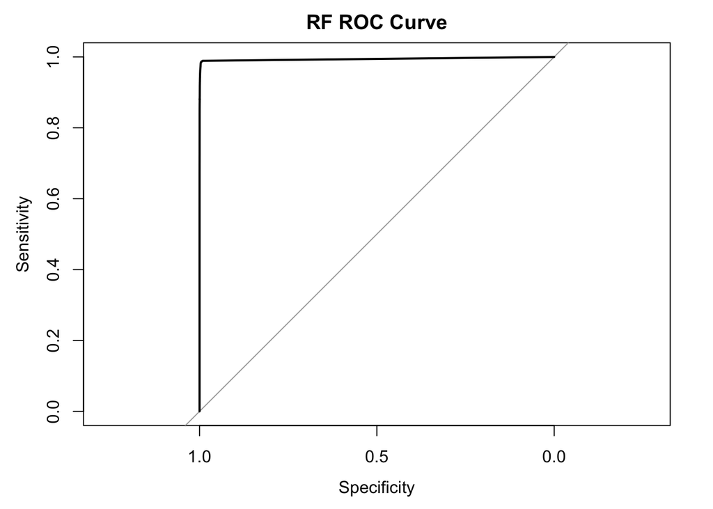

```r
# ROC and AUC
# https://www.youtube.com/watch?v=4jRBRDbJemM&t=739s
# https://www.youtube.com/watch?v=qcvAqAH60Yw&t=196s&ab_channel=StatQuestwithJoshStarmer
theRFROC <- roc(blueTarps.rf.roc, rf.fitted, plot=TRUE, main = "RF ROC Curve")
```

```r
rf.auc <- theRFROC$auc
rf.auc
```

```
## Area under the curve: 0.9943
```

```r
# Accuracy of Logistic Regression Model (grab the average accuracy of all ten folds)
rf.accuracy <- rf.accuracy / k
rf.accuracy
```

```
## [1] 0.9970589
```

```r
# Average True Positive Rate (TPR)
rf.tpr <- rf.tpr / k
rf.tpr
```

```
## [1] 0.9532803
```

```r
# Average False Positive Rate (FPR)
rf.fpr <- rf.fpr / k
rf.fpr
```

```
## [1] 0.001502459
```

```r
# Average Precision
rf.precision <- rf.precision / k
rf.precision
```

```
## [1] 0.9541453
```

Using the random forest model, we see from the metrics that we get really good performance that performs just as well as the KNN model. We have really high values for our AUC, Accuracy, TPR, and Precision while also having an FPR less than 1%. This is reflected in the ROC curve where it demonstrates that the model does very well and has only a slight kink in the elbow of the plot. The ROC curve was once again built from out-of-sample data.

# SVM - Linear

## Cross-Validation - SVM (Linear)

```r
# https://www.rdocumentation.org/packages/base/versions/3.6.2/topics/append

library(e1071) # Load MASS library for Support Vector Machines (svm)
set.seed(1)

# Set metrics to 0
svm.accuracy <- 0
svm.tpr <- 0
svm.fpr <- 0
svm.precision <- 0
svm.auc <- 0

svm.fitted <- vector()
blueTarps.svm.roc <- vector()
blueTarps.svm.roc <- append(blueTarps.svm.roc, blueTarps[-sample.seed]) # Add test response values to vector for each fold

# Create the Support Vector Machines model
svm.cv <- tune(svm, blueTarps~Blue + Red + Green, data=data[sample.seed,], kernel='linear', probability = TRUE, ranges=list(cost=c(0.001, 0.01, 0.1, 1, 5, 10, 100)))
summary(svm.cv)
```

```
##
## Parameter tuning of 'svm':
##
## - sampling method: 10-fold cross validation
##
## - best parameters:
##  cost
##   100
##
## - best performance: 0.004617331
##
## - Detailed performance results:
##    cost       error  dispersion
## 1 1e-03 0.032099937 0.003170452
## 2 1e-02 0.011353574 0.001669811
## 3 1e-01 0.006198608 0.001117635
## 4 1e+00 0.004965212 0.001366787
## 5 5e+00 0.004680582 0.001451564
## 6 1e+01 0.004712207 0.001622555
## 7 1e+02 0.004617331 0.001462243
```

```r
svm.model <- svm.cv$best.model

# Grab the predictions of the Support Vector Machines model
svm.predict <- predict(svm.model, data[-sample.seed,], probability=TRUE)
svm.probs <- attr(svm.predict, 'probabilities')[,2]
#svm.preds <- predict(svm.model, test)
svm.preds <- rep(0,length(blueTarps[-sample.seed])) # Create vector with all 0s
svm.preds[svm.probs > .25] = 1 # Replace zeros in above vector with 1 if above .5

svm.fitted <- append(svm.fitted, svm.probs) # Add probabilities of each fold to vector

# Grab the confusion matrix values for each fold
svm.tn <- table(svm.preds, blueTarps[-sample.seed])[1] # Grab all the True Negatives
svm.fp <- table(svm.preds, blueTarps[-sample.seed])[2] # Grab all the False Positives
svm.fn <- table(svm.preds, blueTarps[-sample.seed])[3] # Grab all the False Negatives
svm.tp <- table(svm.preds, blueTarps[-sample.seed])[4] # Grab all the True Positives

# Accuracy for each fold
svm.accuracy <- ((svm.tn + svm.tp)/(svm.tn + svm.tp + svm.fn + svm.fp))

# True Positive Rate for each fold
svm.tpr <-(svm.tp / (svm.tp + svm.fn))

# False Positive Rate for each fold
svm.fpr <- (svm.fp / (svm.fp + svm.tn))

# Precision for each fold
svm.precision <- (svm.tp / (svm.tp + svm.fp))
```

## Results - SVM (Linear)

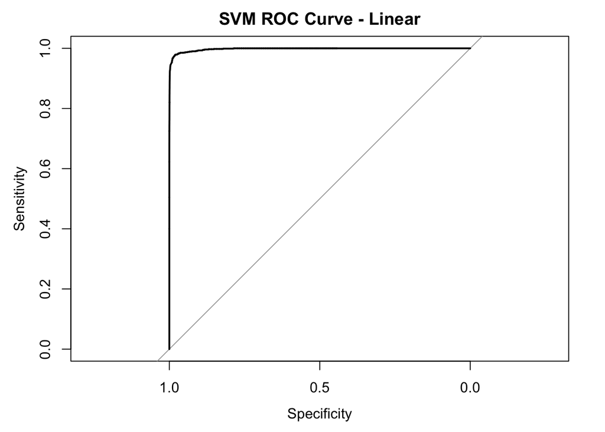

```r
# Cost = 100, CV = .004617331

# ROC and AUC
# https://www.youtube.com/watch?v=4jRBRDbJemM&t=739s
# https://www.youtube.com/watch?v=qcvAqAH60Yw&t=196s&ab_channel=StatQuestwithJoshStarmer
theSVMROC <- roc(blueTarps.svm.roc, svm.fitted, plot=TRUE, main = "SVM ROC Curve - Linear")
```

```r
svm.auc <- theSVMROC$auc
svm.auc
```

```
## Area under the curve: 0.9977
```

```r
# Accuracy of Logistic Regression Model (grab the average accuracy of all ten folds)
svm.accuracy
```

```
## [1] 0.9958572
```

```r
# Average True Positive Rate (TPR)
svm.tpr
```

```
## [1] 0.917577
```

```r
# Average False Positive Rate (FPR)
svm.fpr
```

```
## [1] 0.00156791
```

```r
# Average Precision
svm.precision
```

```
## [1] 0.9506173
```

# SVM - Radial

## Cross-Valdiation - SVM (Radial)

```r
# https://www.rdocumentation.org/packages/base/versions/3.6.2/topics/append

library(e1071) # Load MASS library for Support Vector Machines (svm.radial)
set.seed(1)

# Set metrics to 0
svm.radial.accuracy <- 0
svm.radial.tpr <- 0
svm.radial.fpr <- 0
svm.radial.precision <- 0
svm.radial.auc <- 0

svm.radial.fitted <- vector()
blueTarps.svm.radial.roc <- vector()
blueTarps.svm.radial.roc <- append(blueTarps.svm.radial.roc, blueTarps[-sample.seed]) # Add test response values to vector for each fold


# Create the Support Vector Machines model
svm.radial.cv <- tune(svm, blueTarps~Blue + Red + Green, data=data[sample.seed,], kernel='radial', probability = TRUE, ranges=list(cost=c(0.001, 0.01, 0.1, 1, 5, 10, 100), gamma = c(0.5,1,2,3,4)))
summary(svm.radial.cv)
```

```
##
## Parameter tuning of 'svm':
##
## - sampling method: 10-fold cross validation
##
## - best parameters:
##  cost gamma
##   100     4
##
## - best performance: 0.002593295
##
## - Detailed performance results:
##     cost gamma       error   dispersion
## 1  1e-03   0.5 0.032099937 0.0031704519
## 2  1e-02   0.5 0.014326376 0.0017260974
```

[output cut: 33 more lines]

```r
svm.radial.model <- svm.radial.cv$best.model

# Grab the predictions of the Support Vector Machines model
svm.radial.predict <- predict(svm.radial.model, data[-sample.seed,], probability=TRUE)
svm.radial.probs <- attr(svm.radial.predict, 'probabilities')[,2]
#svm.radial.preds <- predict(svm.radial.model, test)
svm.radial.preds <- rep(0,length(blueTarps[-sample.seed])) # Create vector with all 0s
svm.radial.preds[svm.radial.probs > .25] = 1 # Replace zeros in above vector with 1 if above .5

svm.radial.fitted <- append(svm.radial.fitted, svm.radial.probs) # Add probabilities of each fold to vector

# Grab the confusion matrix values for each fold
svm.radial.tn <- table(svm.radial.preds, blueTarps[-sample.seed])[1] # Grab all the True Negatives
svm.radial.fp <- table(svm.radial.preds, blueTarps[-sample.seed])[2] # Grab all the False Positives
svm.radial.fn <- table(svm.radial.preds, blueTarps[-sample.seed])[3] # Grab all the False Negatives
svm.radial.tp <- table(svm.radial.preds, blueTarps[-sample.seed])[4] # Grab all the True Positives

# Test Error
svm.radial.te <- mean(svm.radial.preds != blueTarps[-sample.seed])

# Accuracy for each fold
svm.radial.accuracy <- ((svm.radial.tn + svm.radial.tp)/(svm.radial.tn + svm.radial.tp + svm.radial.fn + svm.radial.fp))

# True Positive Rate for each fold
svm.radial.tpr <-  (svm.radial.tp / (svm.radial.tp + svm.radial.fn))

# False Positive Rate for each fold
svm.radial.fpr <- (svm.radial.fp / (svm.radial.fp + svm.radial.tn))

# Precision for each fold
svm.radial.precision <- (svm.radial.tp / (svm.radial.tp + svm.radial.fp))
```

## Results - SVM (Radial)

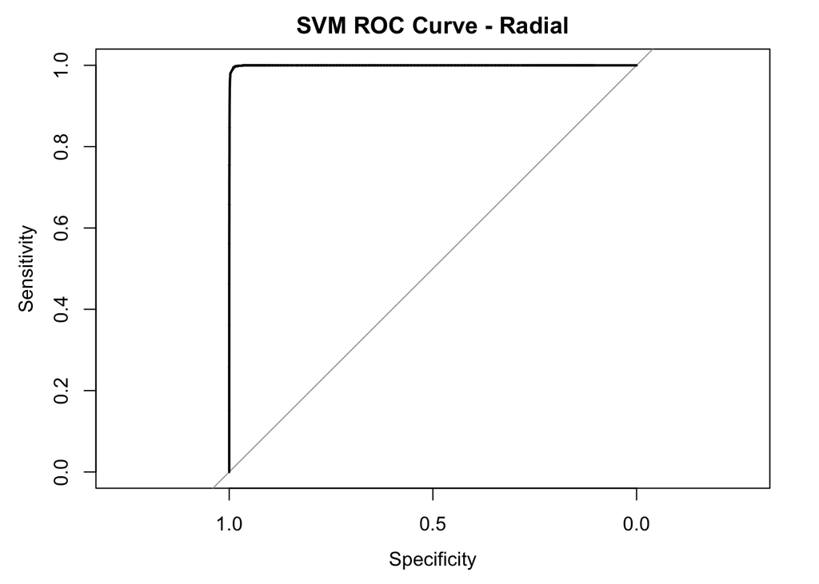

```r
# Cost = 100, Gamma = 4, CV Error = .002593295

# ROC and AUC
# https://www.youtube.com/watch?v=4jRBRDbJemM&t=739s
# https://www.youtube.com/watch?v=qcvAqAH60Yw&t=196s&ab_channel=StatQuestwithJoshStarmer
thesvm.radialROC <- roc(blueTarps.svm.radial.roc, svm.radial.fitted, plot=TRUE, main = "SVM ROC Curve - Radial")
```

```r
svm.radial.auc <- thesvm.radialROC$auc
svm.radial.auc
```

```
## Area under the curve: 0.9995
```

```r
# Accuracy of Logistic Regression Model (grab the average accuracy of all ten folds)
svm.radial.accuracy
```

```
## [1] 0.996964
```

```r
# Average True Positive Rate (TPR)
svm.radial.tpr
```

```
## [1] 0.9682224
```

```r
# Average False Positive Rate (FPR)
svm.radial.fpr
```

```
## [1] 0.002090547
```

```r
# Average Precision
svm.radial.precision
```

```
## [1] 0.9384023
```

# SVM - Polynomial

## Cross-Validation - SVM (Polynomial)

```r
# https://www.rdocumentation.org/packages/base/versions/3.6.2/topics/append

library(e1071) # Load MASS library for Support Vector Machines (svm.poly)
set.seed(1)

# Set metrics to 0
svm.poly.accuracy <- 0
svm.poly.tpr <- 0
svm.poly.fpr <- 0
svm.poly.precision <- 0
svm.poly.auc <- 0

svm.poly.fitted <- vector()
blueTarps.svm.poly.roc <- vector()
blueTarps.svm.poly.roc <- append(blueTarps.svm.poly.roc, blueTarps[-sample.seed]) # Add test response values to vector for each fold


# Create the Support Vector Machines model
svm.poly.cv <- tune(svm, blueTarps~Blue + Red + Green, data=data[sample.seed,], kernel='polynomial', probability = TRUE, ranges=list(cost=c(0.001, 0.01, 0.1, 1, 5, 10, 100), degree = c(1,2,3,4,5)))
summary(svm.poly.cv)
```

```
##
## Parameter tuning of 'svm':
##
## - sampling method: 10-fold cross validation
##
## - best parameters:
##  cost degree
##    10      1
##
## - best performance: 0.004680582
##
## - Detailed performance results:
##     cost degree       error   dispersion
## 1  1e-03      1 0.032099937 0.0031704519
## 2  1e-02      1 0.019765971 0.0019222625
```

[output cut: 33 more lines]

```r
svm.poly.model <- svm.poly.cv$best.model

# Grab the predictions of the Support Vector Machines model
svm.poly.predict <- predict(svm.poly.model, data[-sample.seed,], probability=TRUE)
svm.poly.probs <- attr(svm.poly.predict, 'probabilities')[,2]
#svm.poly.preds <- predict(svm.poly.model, test)
svm.poly.preds <- rep(0,length(blueTarps[-sample.seed])) # Create vector with all 0s
svm.poly.preds[svm.poly.probs > .5] = 1 # Replace zeros in above vector with 1 if above .5

svm.poly.fitted <- append(svm.poly.fitted, svm.poly.probs) # Add probabilities of each fold to vector

# Grab the confusion matrix values for each fold
svm.poly.tn <- table(svm.poly.preds, blueTarps[-sample.seed])[1] # Grab all the True Negatives
svm.poly.fp <- table(svm.poly.preds, blueTarps[-sample.seed])[2] # Grab all the False Positives
svm.poly.fn <- table(svm.poly.preds, blueTarps[-sample.seed])[3] # Grab all the False Negatives
svm.poly.tp <- table(svm.poly.preds, blueTarps[-sample.seed])[4] # Grab all the True Positives

# Test Error
svm.poly.te <- mean(svm.poly.preds != blueTarps[-sample.seed])

# Accuracy for each fold
svm.poly.accuracy <- ((svm.poly.tn + svm.poly.tp)/(svm.poly.tn + svm.poly.tp + svm.poly.fn + svm.poly.fp))

# True Positive Rate for each fold
svm.poly.tpr <- (svm.poly.tp / (svm.poly.tp + svm.poly.fn))

# False Positive Rate for each fold
svm.poly.fpr <- (svm.poly.fp / (svm.poly.fp + svm.poly.tn))

# Precision for each fold
svm.poly.precision <- (svm.poly.tp / (svm.poly.tp + svm.poly.fp))
```

## Results - SVM (Polynomial)

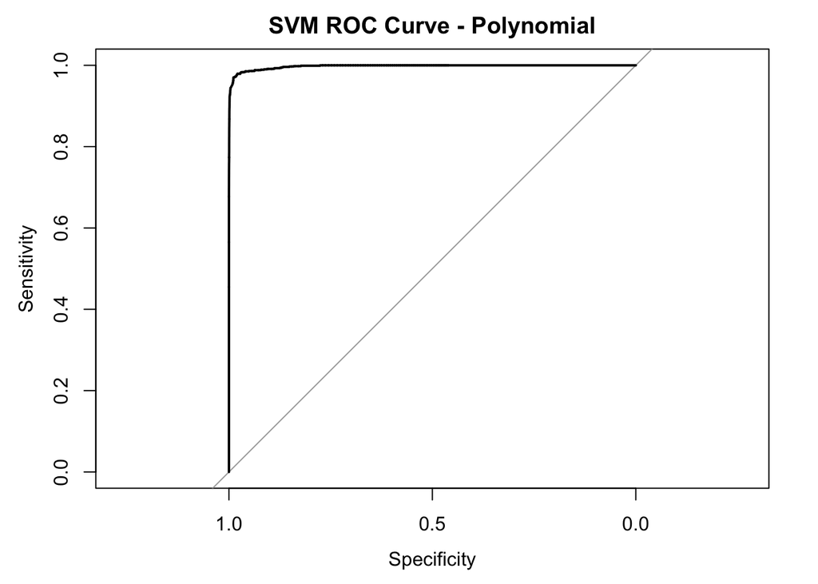

```r
# Cost = 10 ,Degree = 1, CV error = .004680582

# ROC and AUC
# https://www.youtube.com/watch?v=4jRBRDbJemM&t=739s
# https://www.youtube.com/watch?v=qcvAqAH60Yw&t=196s&ab_channel=StatQuestwithJoshStarmer
thesvm.polyROC <- roc(blueTarps.svm.poly.roc, svm.poly.fitted, plot=TRUE, main = "SVM ROC Curve - Polynomial")
```

```r
svm.poly.auc <- thesvm.polyROC$auc
svm.poly.auc
```

```
## Area under the curve: 0.9975
```

```r
# Accuracy of Logistic Regression Model (grab the average accuracy of all ten folds)
svm.poly.accuracy
```

```
## [1] 0.9955093
```

```r
# Average True Positive Rate (TPR)
svm.poly.tpr
```

```
## [1] 0.8907646
```

```r
# Average False Positive Rate (FPR)
svm.poly.fpr
```

```
## [1] 0.001045273
```

```r
# Average Precision
svm.poly.precision
```

```
## [1] 0.9655544
```

For the Support Vector Machine, we looked at SVM models with a linear, radial, and polynomial kernel. From these models, we looked at several different values of their parameters (cost for linear, cost & gamma for radial, and cost & degree for polynomial) to determine the optimal model for each. Using the tune() function, we are able to perform cross validation on each SVM model and go through each possible implementation of the parameters in question. The model with the optimal parameters (or the model with the parameters that provided the lowest CV error) were used to determine the metrics. For the linear kernel the optimal cost value was 100, for radial it was a cost value of 100 and gamma value of 4, and for polynomial it was a cost value of 10 and degree of 1. Using these parameters on each SVM model, the CV errors of the optimal model for each kernel were compared against one another to determine which SVM model to proceed with. The SVM model with the radial kernel (cost = 100, gamma = 4) had the lowest CV error between the 3 models so this is the SVM model we will proceed with this model and associated parameters.

From the results of the SVM - Radial model, we see that our AUC is really good at .9995 (the closest model to 100%). The accuracy of the model is about .997, TPR of .968, FPR of ~.002, and precision value of .938. From this, we see that our model performs pretty well compared to the other models and is similar in performance to our KNN model.

# Tuning Parameters

## KNN - K-Value

```r
# Sources
# https://cran.r-project.org/web/packages/kableExtra/vignettes/awesome_table_in_html.html
# https://www.statology.org/create-table-in-r/

library(kableExtra)

knn.auc.1
```

```
## Area under the curve: 0.9789
```

```r
knn.auc.2
```

```
## Area under the curve: 0.9908
```

```r
knn.auc.3
```

```
## Area under the curve: 0.9945
```

```r
knn.auc.4
```

```
## Area under the curve: 0.9963
```

```r
knn.auc.5
```

```
## Area under the curve: 0.9976
```

```r
knn.auc.6
```

```
## Area under the curve: 0.9982
```

```r
knn.auc.7
```

```
## Area under the curve: 0.9984
```

```r
knn.auc.8
```

```
## Area under the curve: 0.9984
```

```r
knn.auc.9
```

```
## Area under the curve: 0.9989
```

```r
knn.auc.10
```

```
## Area under the curve: 0.9992
```

```r
auc.data <- data.frame(Value_of_K = c("1", "2", "3", "4", "5", "6", "7", "8","9","10"), AUC = c(knn.auc.1,knn.auc.2,knn.auc.3,knn.auc.4,knn.auc.5,knn.auc.6,knn.auc.7,knn.auc.8,knn.auc.9, knn.auc.10))

# Creates embedded table into R Studio
auc.data %>%
  kbl(digits = 4) %>%
  kable_material_dark()
```

| Value_of_K | AUC |
| --- | --- |
| 1 | 0.9789 |
| 2 | 0.9908 |
| 3 | 0.9945 |
| 4 | 0.9963 |
| 5 | 0.9976 |
| 6 | 0.9982 |
| 7 | 0.9984 |
| 8 | 0.9984 |
| 9 | 0.9989 |
| 10 | 0.9992 |

For the value of K for the KNN model, we want to use a K value where the AUC is the highest of all the models observed. The way that this was determined was to use the above code block with different values of K and calculate the AUC for each value of K. From there, the model with value of K that had the highest AUC value would be selected. From my observations, a value of K = 10 had the highest AUC, thus K = 10 was selected for the final model (as seen in the table above).

## Ridge Regression - Optimal Lambda

```r
#plot(cv.output)
optimal.lambda # The optimal lambda value
```

```
## [1] 0.004151254
```

```r
log(optimal.lambda)
```

```
## [1] -5.484345
```

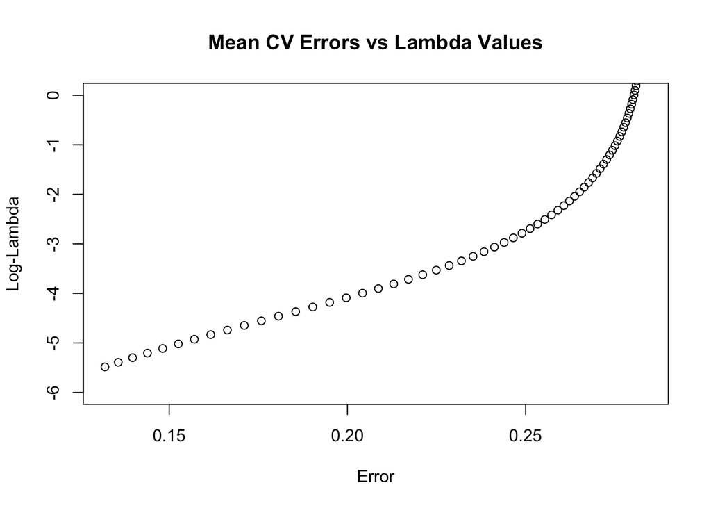

```r
plot(cv.output$cvm, log(cv.output$lambda), xlab = "Error", ylim = c(-6,0), ylab = "Log-Lambda", main = "Mean CV Errors vs Lambda Values") # Erros vs Log Lambda
```

From our ridge regression previously, we determined the optimal lambda value using the cv.glmnet() function and performing the 10-fold cross validation process and use the lambda.min function to get our optimal lambda.From this fitting of the ridge regression model, we were able to get the mean cross-validated error as well as the lambdas for each associated error. Using a plot of the error vs the log of the lambdas, we can see that our optimal lambda value falls where the error is the lowest (the optima lambda is ~.004). The log of our optimal lambda is -5.484345 and we can see the plot above shows that log-lambda value at the lowest error rate.

## Random Forest - “Mtry”

For Random Forest, the tuning parameter that needed to be determined was the “mtry” parameter. This parameter determines the number of predictors that should be considered at each branch/split of the tree. Since our response variable is binary, we are dealing with a classification problem and the rule of thumb with using a Random Forest model on a classification problem is to use the square root of the number of predictors. In this case, we used the square root of 3 (Blue, Green, Red) as our value for “mtry”.

## SVM (Radial Kernel) - Cost & Gamma

```r
summary(svm.radial.cv)
```

```
##
## Parameter tuning of 'svm':
##
## - sampling method: 10-fold cross validation
##
## - best parameters:
##  cost gamma
##   100     4
##
## - best performance: 0.002593295
##
## - Detailed performance results:
##     cost gamma       error   dispersion
## 1  1e-03   0.5 0.032099937 0.0031704519
## 2  1e-02   0.5 0.014326376 0.0017260974
```

[output cut: 33 more lines]

For the Support Vector Machine, a variety of cost and gamma parameters were selected to determine the optimal parameters to use on the SVM - Radial model. Using cross-validation, CV errors were calculated for each combination of cost and gamma values. The cost values examined were .001, 0.01, 0.1, 1, 5, 10, and 100 while the gamma values examined were 0.5, 1,2, 3, and 4. The cost and gamma combination that had the lowest CV error for the SVM- Radial model was a cost value of 100 and gamma value of 4.

A similar approach was used for the linear and polynomial kernels but are not mentioned here since they were not selected as the SVM model of choice.

# Threshold Selection

The values for thresholds were updated between Part 1 and Part 2 of this project to incorporate different values in the threshold (originally all threshold values were .25). For threshold selection, I made some assumptions to what the threshold value would be for each model. For the threshold, we want to keep in mind the fact that we are primarily concerned with identifying blue tarps correctly and have a secondary objective of doing it within a resource constraint. To this end, we want to examine the TPR value of each range and do our best to reduce the number of false negatives while keeping in mind the resource constraint. For this, I analyzed the TPR value of each model and assumed that a marginal benefit was received for every 5% increase in the TPR rate. For example, if the model has a TPR of 93%, I will decrease my threshold if it was possible to raise the TPR to 95%. If not, I would increase my threshold to be as close to 90% as possible. I assumed a TPR between 90-95% (for example) was not enough to justify reducing the threshold to get to that value unless the TPR was able to reach 95% (i.e. I would only set my TPR near 90% or 95% in this example case) . Please note that many threshold values were examined but were not included as part of the code – only the selected value was incorporated into the code.

In a real-world scenario, it made not be possible to expend the amount of resources to justify threshold levels that are super low (for example at 1%) because of financial constraints and limited labor resources to be able to support some of the models high TPR rates and high FPR rates.

Additionally, the thresholds were set to the estimated/posterior probabilities of each model - these are the probabilities that the prediction is a blue tarp. Any of the probabilities greater than the threshold value were deemed to be a blue tarp and any probability below was predicted not to be a blue tarp. The predictions then were placed into a vector and compared in the confusion matrix with the values in the response of the test data.

# Cross-Validation Performance Table

```r
# Sources
# https://cran.r-project.org/web/packages/kableExtra/vignettes/awesome_table_in_html.html
# https://www.statology.org/create-table-in-r/

library(kableExtra) # Load library to create embedded table

# Create a data frame for required metrics
theTable <- data.frame(Model=c("Logistic Regression", "LDA", "QDA", "KNN", "Penalized Log. Reg.", "Random Forest", "SVM - Radial"),Tuning =c("NA", "NA", "NA", 10, round(optimal.lambda,4), round(sqrt(3),4), "Cost - 100; Gamma - 4"), AUROC = c(log.auc, lda.auc, qda.auc, knn.auc.10, ridge.auc, rf.auc, svm.auc), Threshold = c(.14,.09,.1,.59,.01,.45, .25), Accuracy = c(log.accuracy, lda.accuracy, qda.accuracy, knn.accuracy, ridge.accuracy,rf.accuracy, svm.accuracy), TPR = c(tpr, lda.tpr, qda.tpr, knn.tpr, ridge.tpr, rf.tpr, svm.tpr), FPR = c(fpr, lda.fpr, qda.fpr, knn.fpr, ridge.fpr, rf.fpr, svm.fpr), Precision = c(log.precision, lda.precision, qda.precision, knn.precision, ridge.precision, rf.precision, svm.precision))

theTable # See the data frame created
```

```
##                 Model                Tuning     AUROC Threshold  Accuracy
## 1 Logistic Regression                    NA 0.9984860      0.14 0.9915403
## 2                 LDA                    NA 0.9888569      0.09 0.9821635
## 3                 QDA                    NA 0.9981887      0.10 0.9896902
## 4                 KNN                    10 0.9991983      0.59 0.9970431
## 5 Penalized Log. Reg.                0.0042 0.9808880      0.01 0.1675785
## 6       Random Forest                1.7321 0.9942839      0.45 0.9970589
## 7        SVM - Radial Cost - 100; Gamma - 4 0.9976702      0.25 0.9958572
##         TPR         FPR  Precision
## 1 0.9517734 0.007155075 0.81442359
## 2 0.8500854 0.013460103 0.67616493
## 3 0.9014926 0.007384430 0.80174435
## 4 0.9540529 0.001534872 0.95313162
## 5 1.0000000 0.859802705 0.03684731
## 6 0.9532803 0.001502459 0.95414531
## 7 0.9175770 0.001567910 0.95061728
```

```r
# Creates embedded table into R Studio
theTable %>%
  kbl(digits = 4) %>%
  kable_material_dark()
```

| Model | Tuning | AUROC | Threshold | Accuracy | TPR | FPR | Precision |
| --- | --- | --- | --- | --- | --- | --- | --- |
| Logistic Regression | NA | 0.9985 | 0.14 | 0.9915 | 0.9518 | 0.0072 | 0.8144 |
| LDA | NA | 0.9889 | 0.09 | 0.9822 | 0.8501 | 0.0135 | 0.6762 |
| QDA | NA | 0.9982 | 0.10 | 0.9897 | 0.9015 | 0.0074 | 0.8017 |
| KNN | 10 | 0.9992 | 0.59 | 0.9970 | 0.9541 | 0.0015 | 0.9531 |
| Penalized Log. Reg. | 0.0042 | 0.9809 | 0.01 | 0.1676 | 1.0000 | 0.8598 | 0.0368 |
| Random Forest | 1.7321 | 0.9943 | 0.45 | 0.9971 | 0.9533 | 0.0015 | 0.9541 |
| SVM - Radial | Cost - 100; Gamma - 4 | 0.9977 | 0.25 | 0.9959 | 0.9176 | 0.0016 | 0.9506 |

# Hold-Out Data Section - Part 2

## Import Hold-Out Data

```r
# http://www.sthda.com/english/wiki/reading-data-from-txt-csv-files-r-base-functions
# https://statisticsglobe.com/add-header-to-data-frame-in-r

hold1 <- read.table("orthovnir057_ROI_NON_Blue_Tarps.txt", header=FALSE, comment.char =";", col.names = c("ID", "X", "Y", "Map X", "Map Y", "Lat", "Lon", "B1", "B2", "B3"))
hold1$Type <- "Other"
hold2 <- read.table("orthovnir067_ROI_Blue_Tarps.txt", header=FALSE, comment.char =";", col.names = c("ID", "X", "Y", "Map X", "Map Y", "Lat", "Lon", "B1", "B2", "B3"))
hold2$Type <- "Blue Tarp"
hold3 <- read.table("orthovnir067_ROI_NOT_Blue_Tarps.txt", header=FALSE, comment.char =";", col.names = c("ID", "X", "Y", "Map X", "Map Y", "Lat", "Lon", "B1", "B2", "B3"))
hold3$Type <- "Other"
hold4 <- read.table("orthovnir069_ROI_Blue_Tarps.txt", header=FALSE, comment.char =";", col.names = c("ID", "X", "Y", "Map X", "Map Y", "Lat", "Lon", "B1", "B2", "B3"))
hold4$Type <- "Blue Tarp"
hold5 <- read.table("orthovnir069_ROI_NOT_Blue_Tarps.txt", header=FALSE, comment.char =";", col.names = c("ID", "X", "Y", "Map X", "Map Y", "Lat", "Lon", "B1", "B2", "B3"))
hold5$Type <- "Other"
hold6 <- read.table("orthovnir078_ROI_Blue_Tarps.txt", header=FALSE, comment.char =";", col.names = c("ID", "X", "Y", "Map X", "Map Y", "Lat", "Lon", "B1", "B2", "B3"))
hold6$Type <- "Blue Tarp"
hold7 <- read.table("orthovnir078_ROI_NON_Blue_Tarps.txt", header=FALSE, comment.char =";", col.names = c("ID", "X", "Y", "Map X", "Map Y", "Lat", "Lon", "B1", "B2", "B3"))
hold7$Type <- "Other"


holdout <- rbind(hold1, hold2, hold3, hold4, hold5, hold6, hold7)


## LOOK AT A PAIRS PLOT TO DETERMINE RGB in holdout data; can also try density plot or violin plot or histograms
```

Using the read.table() function, each text file that makes up the hold out data was imported into the R script. The parameter comment.char was used in order to read the rows that had a semi-colon at the beginning and removes it from the data being imported. One of the rows removed has the header row so the parameter col.names must be used in order to define the columns in each data set. We also see that one of the text files provided was duplicated data that did not need to be imported (duplicated data from the “orthovnir067_ROI_Blue_Tarps.txt” file). To combine the data frames together, the rbind() function was used to combine the rows of the data sets into one big data frame to form the holdout data set.

## Exploratory Data Analysis - Holdout

```r
holdout$blueTarpsHold <- ifelse(holdout$Type == "Blue Tarp", 1, 0)
holdout$blueTarpsHold <- factor(holdout$blueTarpsHold)
blueTarpsHold <-holdout$blueTarpsHold
attach(holdout)
```

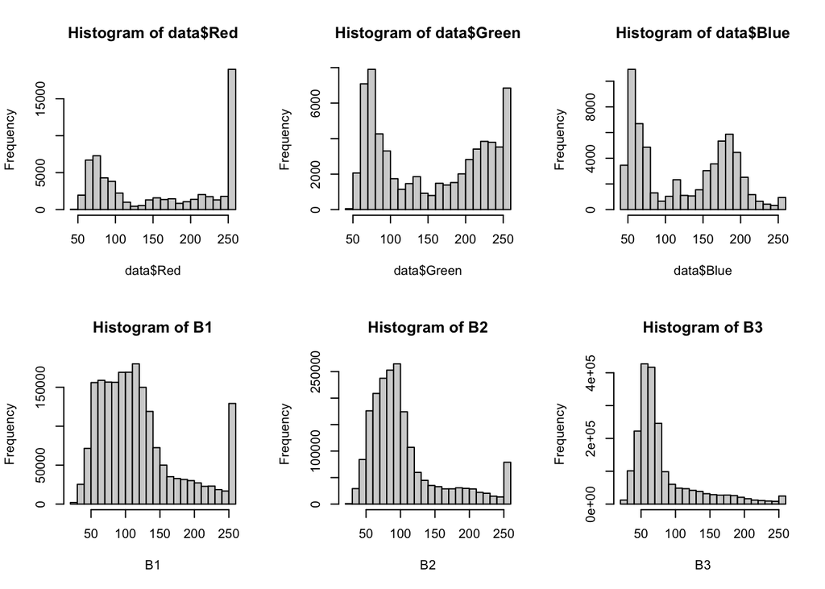

```r
par(mfrow=c(2,3))
hist(data$Red)
hist(data$Green)
hist(data$Blue)
hist(B1)
hist(B2)
hist(B3)
```

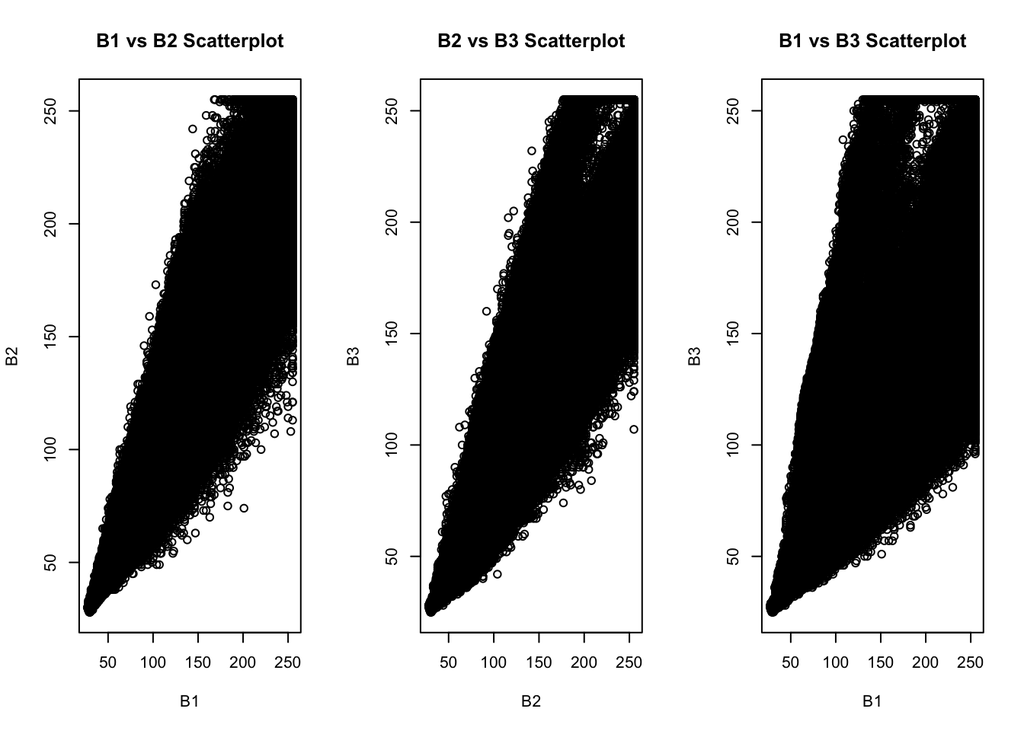

```r
par(mfrow=c(1,3))
plot(B1, B2, main = "B1 vs B2 Scatterplot")
plot(B2, B3, main = "B2 vs B3 Scatterplot")
plot(B1, B3, main = "B1 vs B3 Scatterplot")
```

```r
# Source: https://stackoverflow.com/questions/6081439/changing-column-names-of-a-data-frame
colnames(holdout)[8] <- c("Red")
colnames(holdout)[9] <- c("Green")
colnames(holdout)[10] <- c("Blue")
```

For our EDA on the holdout data set, we use histograms to compare the distributions of B1, B2, and B3 with the distributions of Red, Blue, Green from our training set. Comparing the distributions of the attributes from the holdout data set and the training data set, we make the connection that B1 = Red, B2 = Green, and B3 = Blue. From this, the columns in the holdout data set need to be relabeled as such.

Also, from our scatterplots, we see that the three predictors in question (B1, B2, and B3) seem to have linear relationships between one another (similar to what we saw with Red, Green, Blue in our training data set as well).

## Method Approach - Part 2

Note that the only major change from Part 1is the test data (i.e. holdout data) that the models are being predicted on. Using the same prediction methods and code implementation from Part 1, the following code blocks will be taking the models determined from Part 1 (with same threshold values, predictors, etc,) and be predicted onto the holdout data set. The same metrics from before (AUC, Accuracy, TPR, FPR, and Precision) will all be re-calculated into a new performance table to determine which model fared the best. ROC curves will all be developed as well and built from the out-of-sample data too. There will not be any cross-validation or training necessary since that was already performed in the code for Part 1.

# Holdout Predictions

## Logistic Regression - Holdout

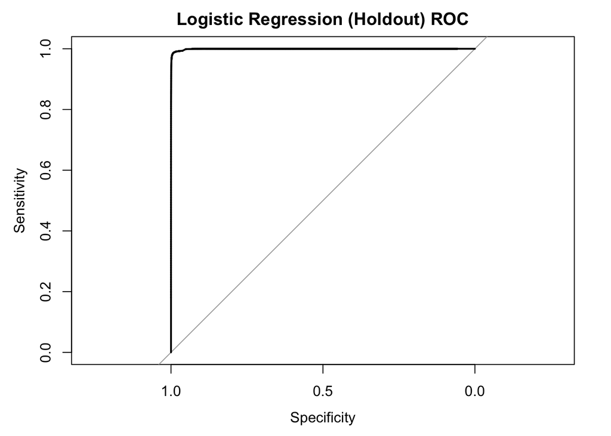

```r
# Use logistic regression model to predict on the holdout data
log.hold.probs <- predict(log.result, holdout, type='response')
log.hold.preds <- rep(0, nrow(holdout))
log.hold.preds[log.hold.probs > .14] = 1

# Create confusion matrix and grab values
log.hold.tn <- table(log.hold.preds, blueTarpsHold)[1] # Grab all the True Negatives
log.hold.fp <- table(log.hold.preds, blueTarpsHold)[2] # Grab all the False Positives
log.hold.fn <- table(log.hold.preds, blueTarpsHold)[3] # Grab all the False Negatives
log.hold.tp <- table(log.hold.preds, blueTarpsHold)[4] # Grab all the True Positives

#AUC
log.hold.roc <- roc(blueTarpsHold, log.hold.probs, plot=TRUE, main = "Logistic Regression (Holdout) ROC")
```

```r
log.hold.auc <- log.hold.roc$auc
log.hold.auc
```

```
## Area under the curve: 0.9994
```

```r
# Accuracy for each fold
log.hold.accuracy <-  ((log.hold.tn + log.hold.tp)/(log.hold.tn + log.hold.tp + log.hold.fn + log.hold.fp))
log.hold.accuracy
```

```
## [1] 0.939441
```

```r
# True Positive Rate for each fold
log.hold.tpr <-(log.hold.tp / (log.hold.tp + log.hold.fn))
log.hold.tpr
```

```
## [1] 0.9991713
```

```r
# False Positive Rate for each fold
log.hold.fpr <- (log.hold.fp / (log.hold.fp + log.hold.tn))
log.hold.fpr
```

```
## [1] 0.06099371
```

```r
# Precision for each fold
log.hold.precision <- (log.hold.tp / (log.hold.tp + log.hold.fp))
log.hold.precision
```

```
## [1] 0.1065178
```

## LDA - Holdout

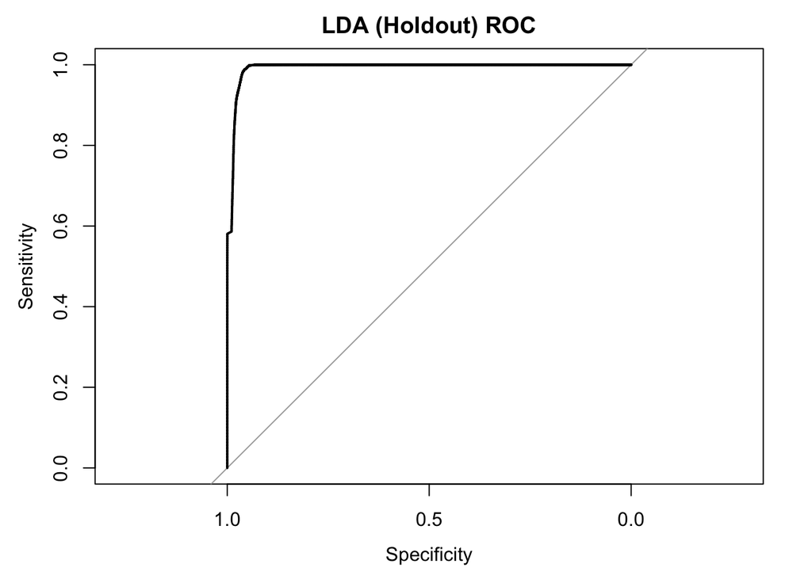

```r
# Use LDA  model to predict on the holdout data
lda.hold.probs <- predict(lda.model, holdout)
lda.hold.probs <- lda.hold.probs$posterior[,2]
lda.hold.preds <- rep(0, nrow(holdout))
lda.hold.preds[lda.hold.probs > .09] = 1

# Create confusion matrix and grab values
lda.hold.tn <- table(lda.hold.preds, blueTarpsHold)[1] # Grab all the True Negatives
lda.hold.fp <- table(lda.hold.preds, blueTarpsHold)[2] # Grab all the False Positives
lda.hold.fn <- table(lda.hold.preds, blueTarpsHold)[3] # Grab all the False Negatives
lda.hold.tp <- table(lda.hold.preds, blueTarpsHold)[4] # Grab all the True Positives

#AUC
lda.hold.roc <- roc(blueTarpsHold, lda.hold.probs, plot=TRUE, main = "LDA (Holdout) ROC")
```

```r
lda.hold.auc <- lda.hold.roc$auc
lda.hold.auc
```

```
## Area under the curve: 0.9921
```

```r
# Accuracy for each fold
lda.hold.accuracy <-  ((lda.hold.tn + lda.hold.tp)/(lda.hold.tn + lda.hold.tp + lda.hold.fn + lda.hold.fp))
lda.hold.accuracy
```

```
## [1] 0.9777789
```

```r
# True Positive Rate for each fold
lda.hold.tpr <-(lda.hold.tp / (lda.hold.tp + lda.hold.fn))
lda.hold.tpr
```

```
## [1] 0.908011
```

```r
# False Positive Rate for each fold
lda.hold.fpr <- (lda.hold.fp / (lda.hold.fp + lda.hold.tn))
lda.hold.fpr
```

```
## [1] 0.02171336
```

```r
# Precision for each fold
lda.hold.precision <- (lda.hold.tp / (lda.hold.tp + lda.hold.fp))
lda.hold.precision
```

```
## [1] 0.2333233
```

## QDA - Holdout

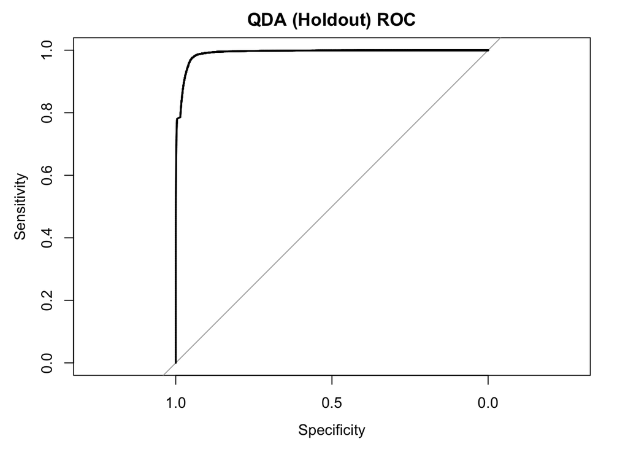

```r
# Use QDA model to predict on the holdout data
qda.hold.probs <- predict(qda.model, holdout)
qda.hold.probs <- qda.hold.probs$posterior[,2]
qda.hold.preds <- rep(0, nrow(holdout))
qda.hold.preds[qda.hold.probs > .1] = 1

# Create confusion matrix and grab values
qda.hold.tn <- table(qda.hold.preds, blueTarpsHold)[1] # Grab all the True Negatives
qda.hold.fp <- table(qda.hold.preds, blueTarpsHold)[2] # Grab all the False Positives
qda.hold.fn <- table(qda.hold.preds, blueTarpsHold)[3] # Grab all the False Negatives
qda.hold.tp <- table(qda.hold.preds, blueTarpsHold)[4] # Grab all the True Positives

#AUC
qda.hold.roc <- roc(blueTarpsHold, qda.hold.probs, plot=TRUE, main = "QDA (Holdout) ROC")
```

```r
qda.hold.auc <- qda.hold.roc$auc
qda.hold.auc
```

```
## Area under the curve: 0.9916
```

```r
# Accuracy for each fold
qda.hold.accuracy <-  ((qda.hold.tn + qda.hold.tp)/(qda.hold.tn + qda.hold.tp + qda.hold.fn + qda.hold.fp))
qda.hold.accuracy
```

```
## [1] 0.9813599
```

```r
# True Positive Rate for each fold
qda.hold.tpr <-(qda.hold.tp / (qda.hold.tp + qda.hold.fn))
qda.hold.tpr
```

```
## [1] 0.8247928
```

```r
# False Positive Rate for each fold
qda.hold.fpr <- (qda.hold.fp / (qda.hold.fp + qda.hold.tn))
qda.hold.fpr
```

```
## [1] 0.01750065
```

```r
# Precision for each fold
qda.hold.precision <- (qda.hold.tp / (qda.hold.tp + qda.hold.fp))
qda.hold.precision
```

```
## [1] 0.2553888
```

## KNN - Holdout

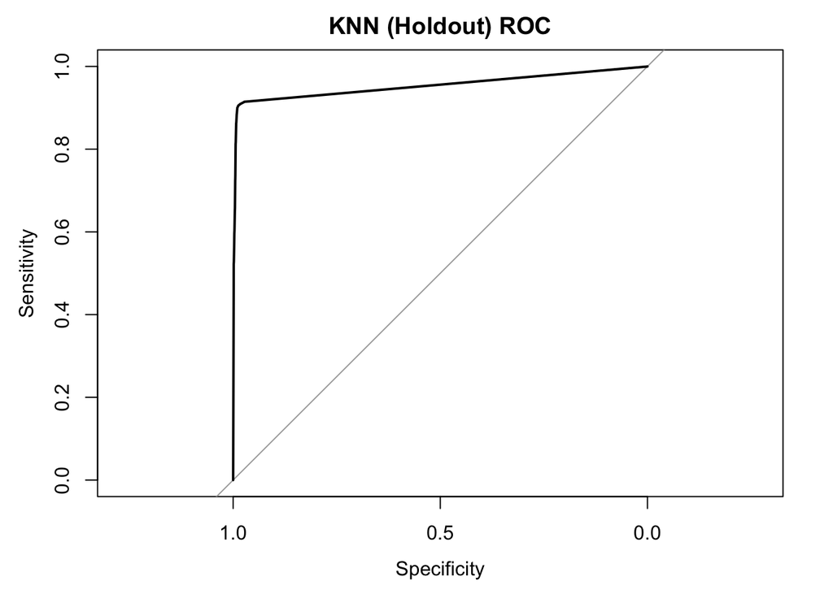

```r
knn.model <- knn3(blueTarps~Red + Green + Blue, data = train, k = 10)

# Use KNN model to predict on the holdout data
knn.hold.probs <- predict(knn.model, holdout, type="prob")[,2]
knn.hold.preds <- rep(0, nrow(holdout))
knn.hold.preds[knn.hold.probs > .59] = 1

# Create confusion matrix and grab values
knn.hold.tn <- table(knn.hold.preds, blueTarpsHold)[1] # Grab all the True Negatives
knn.hold.fp <- table(knn.hold.preds, blueTarpsHold)[2] # Grab all the False Positives
knn.hold.fn <- table(knn.hold.preds, blueTarpsHold)[3] # Grab all the False Negatives
knn.hold.tp <- table(knn.hold.preds, blueTarpsHold)[4] # Grab all the True Positives

#AUC
knn.hold.roc <- roc(blueTarpsHold, knn.hold.probs, plot=TRUE, main = "KNN (Holdout) ROC")
```

```r
knn.hold.auc <- knn.hold.roc$auc
knn.hold.auc
```

```
## Area under the curve: 0.9536
```

```r
# Accuracy for each fold
knn.hold.accuracy <-  ((knn.hold.tn + knn.hold.tp)/(knn.hold.tn + knn.hold.tp + knn.hold.fn + knn.hold.fp))
knn.hold.accuracy
```

```
## [1] 0.9927142
```

```r
# True Positive Rate for each fold
knn.hold.tpr <-(knn.hold.tp / (knn.hold.tp + knn.hold.fn))
knn.hold.tpr
```

```
## [1] 0.8127762
```

```r
# False Positive Rate for each fold
knn.hold.fpr <- (knn.hold.fp / (knn.hold.fp + knn.hold.tn))
knn.hold.fpr
```

```
## [1] 0.005976287
```

```r
# Precision for each fold
knn.hold.precision <- (knn.hold.tp / (knn.hold.tp + knn.hold.fp))
knn.hold.precision
```

```
## [1] 0.4974218
```

## Ridge Regression - Holdout

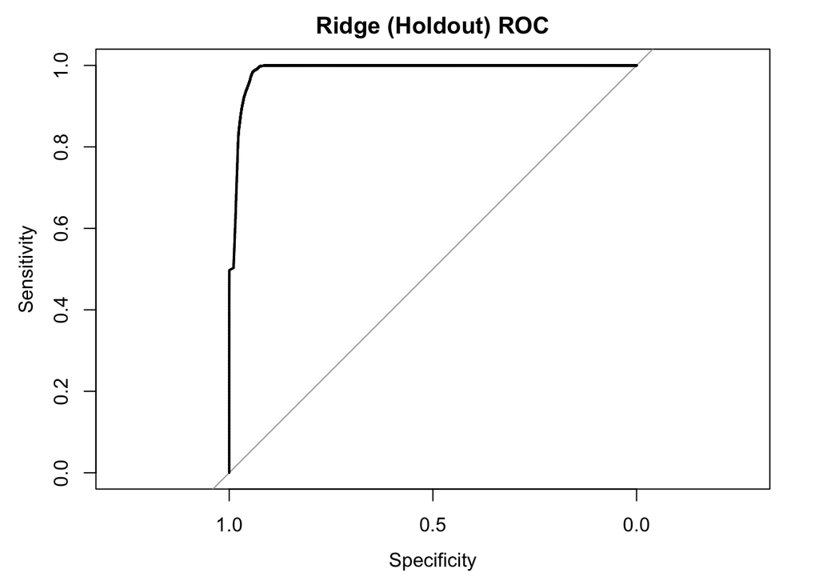

```r
# Create a matrix with the new holdout data and predict using the ridge regression model
set.seed(1)
matrix.hold.pred <- model.matrix(blueTarpsHold~Red+Blue+Green, holdout)[,-1]
ridge.hold.probs <- predict(ridge.model, s = optimal.lambda, newx = matrix.hold.pred[1:nrow(holdout),], type = 'response')

ridge.hold.preds <- rep(0, nrow(holdout))
ridge.hold.preds[ridge.hold.probs > .01] = 1

# Grab the values from the confusion matrix values for calculating metrics
ridge.hold.tn <- table(ridge.hold.preds, blueTarpsHold)[1] # Grab all the True Negatives
ridge.hold.fp <- table(ridge.hold.preds, blueTarpsHold)[2] # Grab all the False Positives
ridge.hold.fn <- table(ridge.hold.preds, blueTarpsHold)[3] # Grab all the False Negatives
ridge.hold.tp <- table(ridge.hold.preds, blueTarpsHold)[4] # Grab all the True Positives

#AUC
ridge.hold.roc <- roc(blueTarpsHold, ridge.hold.probs, plot=TRUE, main = "Ridge (Holdout) ROC")
```

```r
ridge.hold.auc <- ridge.hold.roc$auc
ridge.hold.auc
```

```
## Area under the curve: 0.9879
```

```r
# Accuracy for each fold
ridge.hold.accuracy <-  ((ridge.hold.tn + ridge.hold.tp)/(ridge.hold.tn + ridge.hold.tp + ridge.hold.fn + ridge.hold.fp))
ridge.hold.accuracy
```

```
## [1] 0.5505941
```

```r
# True Positive Rate for each fold
ridge.hold.tpr <-(ridge.hold.tp / (ridge.hold.tp + ridge.hold.fn))
ridge.hold.tpr
```

```
## [1] 1
```

```r
# False Positive Rate for each fold
ridge.hold.fpr <- (ridge.hold.fp / (ridge.hold.fp + ridge.hold.tn))
ridge.hold.fpr
```

```
## [1] 0.4526765
```

```r
# Precision for each fold
ridge.hold.precision <- (ridge.hold.tp / (ridge.hold.tp + ridge.hold.fp))
ridge.hold.precision
```

```
## [1] 0.01582221
```